# Closeness Centrality

**Purpose**: Explore how a rodents place in the network based on closeness centrality can be used to explain Hantavirus host status.

Load packages

```r
library(forcats)
library(ggplot2)
library(fmsb)
```

### Quantiles

Calculate quantiles for closeness centrality and assign them to each rodent in a new column.

```r
closcen<- read.csv("ClosenessCentralityHanta.csv", header=TRUE) ## From Gephi

closcen<- subset(closcen, closnesscentrality>0) # get rid of rodents without connections
sorted<-closcen[order(closcen$closnesscentrality ),]
quan<-quantile(closcen$closnesscentrality)

genrod<- subset(closcen, closnesscentrality> quan[4])
midrod<- subset(closcen, closnesscentrality<= quan[4] & closnesscentrality> quan[3])
lowrod <- subset(closcen, closnesscentrality<= quan[3] & closnesscentrality> quan[2])
specrod<-subset(closcen, closnesscentrality<= quan[2] & closnesscentrality>= quan[1])

genrod$Quantile<- c(1,1,1,1,1,1,1,1,1,1,1,1)
midrod$Quantile<-c(2,2,2,2,2,2,2,2,2,2,2)
lowrod$Quantile <- c(3,3,3,3,3,3,3,3,3,3,3,3)
specrod$Quantile<- c(4,4,4,4,4,4,4,4,4,4,4,4,4,4)

grod <- genrod[,c("Id", "Quantile", "closnesscentrality")]
mrod<- midrod[,c("Id", "Quantile", "closnesscentrality")]
lrod<- lowrod[,c("Id", "Quantile", "closnesscentrality")]
srod<- specrod[,c("Id", "Quantile", "closnesscentrality")]
netrod<-rbind(grod, mrod, lrod, srod)
```

Plot the closeness centrality quantiles.

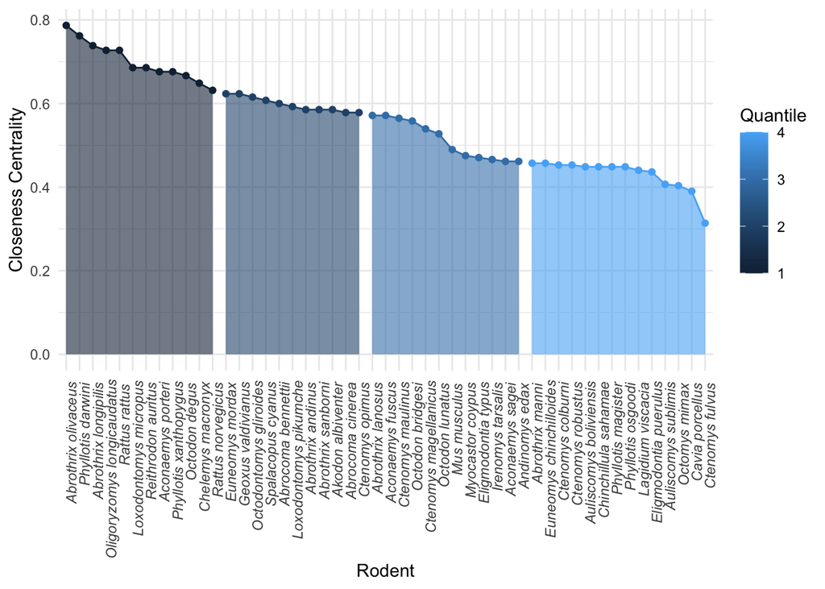

```r
ggplot(netrod, aes(x = fct_reorder(Id, closnesscentrality, .desc=TRUE ), y = closnesscentrality, group=Quantile)) +
  geom_line(aes(colour= Quantile)) +
  geom_area(data=netrod[netrod$Quantile=="1",],mapping=aes(fill=1), alpha=.6, show.legend = F)+
  geom_area(data=netrod[netrod$Quantile=="2",],mapping=aes(fill=2), alpha=.6, show.legend = F)+
  geom_area(data=netrod[netrod$Quantile=="3",],mapping=aes(fill=3), alpha=.6, show.legend = F)+
  geom_area(data=netrod[netrod$Quantile=="4",],mapping=aes(fill= 4), alpha=.6, show.legend = F)+
  geom_point(aes(colour=Quantile), show.legend = FALSE)+
  theme_minimal()+
  theme(axis.text.x=element_text(angle=90, hjust=0.95,vjust=1, face="italic")) + xlab("Rodent") +ylab("Closeness Centrality")
```

### Range, Closeness Centrality, and Total Relationships and Parasites

Explore relationships between range size with closeness centrality, total parasites, and total relationships

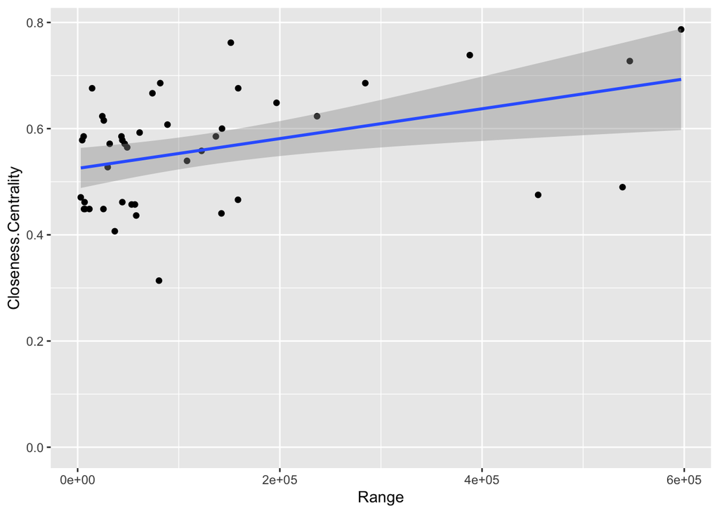

```r
cc<- read.csv("AllDataConsol.csv", header=TRUE) #file has rodent names, range size, total parasites, total relationships, and closeness centrality
par(mfrow=c(1,3))
closecen<-ggplot(cc, aes(x=Range, y=Closeness.Centrality))+
  geom_point()+
  stat_smooth(method="glm")
closecen
```

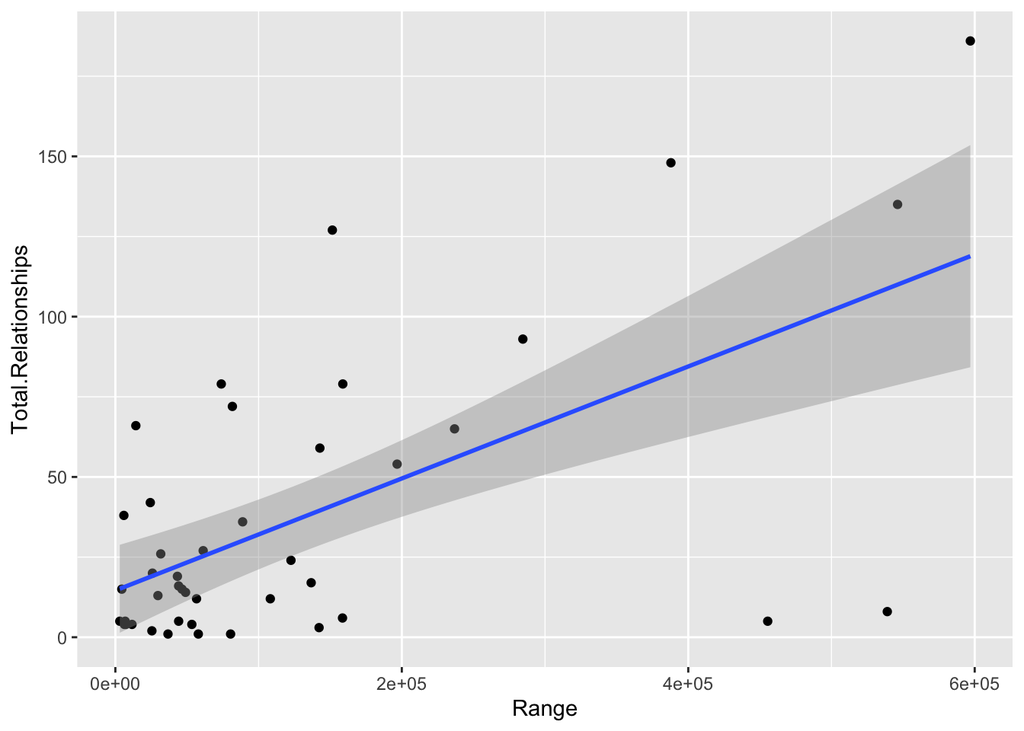

```r
trela<-ggplot(cc, aes(x=Range, y=Total.Relationships))+
  geom_point()+
  stat_smooth(method="glm")
trela
```

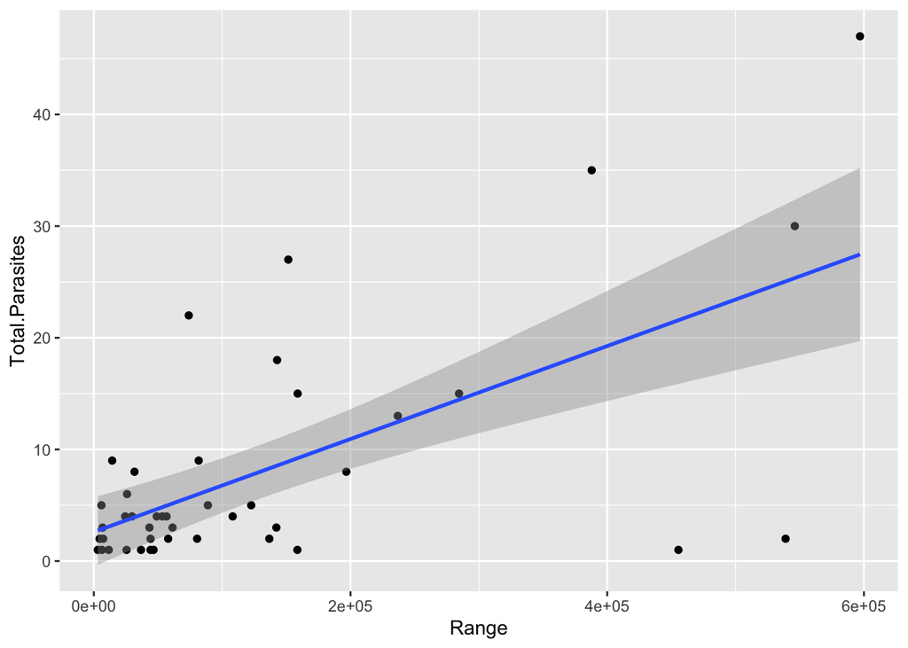

```r
tpara<-ggplot(cc, aes(x=Range, y= Total.Parasites))+
  geom_point()+
  stat_smooth(method="glm")
tpara
```

```r
cclm<- glm( Range ~ Closeness.Centrality, data=cc)
p_cc<-coef(summary(cclm))[2,4]
tplm<- glm( Range ~Total.Parasites , data=cc)
p_tp<-coef(summary(tplm))[2,4]
trlm<- glm( Range ~ Total.Relationships, data=cc)
p_tr<- coef(summary(trlm))[2,4]
```

Range has a significant relationship with closeness centrality (p= 0.0065876), total relationships (p= 1.5202329^{-5}), and total parasites (p= 5.5458519^{-6}).

Compare total parasites and total relationships per rodent on the same plot

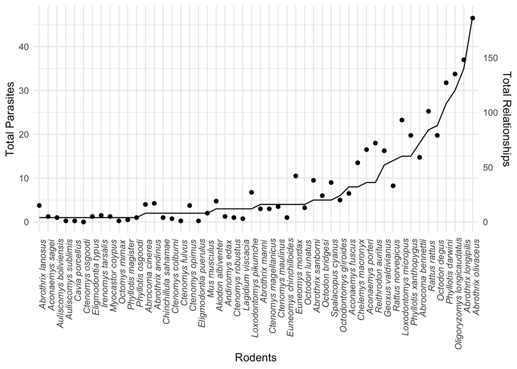

```r
ratio<- median(cc$Total.Relationships)/ median(cc$Total.Parasites)
n<-4
ggplot(cc, aes(x=fct_reorder(Rodent, Total.Parasites)))+
  geom_line(aes(y=Total.Parasites, group=F), color = 'black') +
  geom_point(aes(y=Total.Relationships/n, group= F))+ theme_minimal() +
  theme(axis.text.x=element_text(angle=90, hjust=0.95,vjust=1, face="italic") )+
  xlab("Rodents") +
  scale_y_continuous(
    name = "Total Parasites",
    sec.axis = sec_axis( trans=~.*4, name="Total Relationships")
  )
```

On average, an ectoparasite connects a rodent to 4.2857143 other rodents. In the plot above, when the dot (total relationships) falls above the line (total parasites) for a rodent, it means that rodents parasites connect it to more rodents than the average. When it falls below the line, the parasites connect it to less rodents on average.

### Hantavirus

Next, use a binomial logistic regression to test how well closeness centrality predicts hantavirus hosts

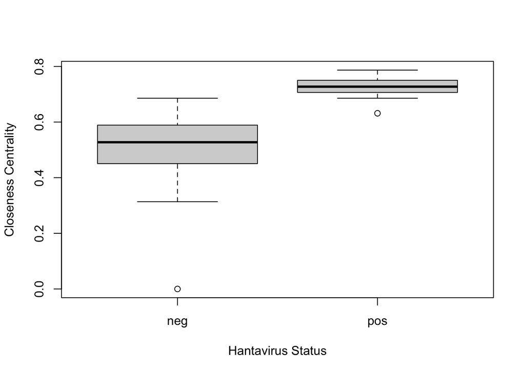

```r
cchanta<- read.csv("ClosenessCentralityHanta.csv", header=T) # file with CC and hantavirus status 0/1 for neg/pos

boxplot(closnesscentrality~Hanta, data=cchanta, xlab = "Hantavirus Status", ylab= "Closeness Centrality")
```

Based on the boxplot, it seems as though known Hantavirus hosts have a higher closeness centrality. Now we will use a binomial logistic regression model to test this.

```r
log<-glm(X ~ closnesscentrality, family= 'binomial', data= cchanta ) #X is a column with 0 and 1 for negative and positive hantavirus status
R2<- NagelkerkeR2(log)
p_hanta<- coef(summary(log))[2,4]
summary(log)
```

```
##
## Call:
## glm(formula = X ~ closnesscentrality, family = "binomial", data = cchanta)
##
## Deviance Residuals:
##      Min        1Q    Median        3Q       Max
## -1.14401  -0.11964  -0.00706  -0.00334   2.35134
##
## Coefficients:
##                    Estimate Std. Error z value Pr(>|z|)
## (Intercept)          -33.27      13.73  -2.423   0.0154 *
## closnesscentrality    48.40      20.24   2.391   0.0168 *
## ---
## Signif. codes:  0 '***' 0.001 '**' 0.01 '*' 0.05 '.' 0.1 ' ' 1
##
## (Dispersion parameter for binomial family taken to be 1)
##
##     Null deviance: 40.496  on 49  degrees of freedom
## Residual deviance: 12.234  on 48  degrees of freedom
## AIC: 16.234
##
## Number of Fisher Scoring iterations: 9
```

In the binomial logistic regression model, closeness centrality explains 78% of the variance in Hantavirus status among rodents (p= 0.0168109, R2= 0.7778293)

Next, we will use a Phylogenetic logistic regression for binary dependent variables to see how strong phylogentic signal is.

Load packages

```r
library(picante)
library(ape)
library(phylotools)
library(phytools)
library(geotax)
library(reshape2)
library(ggplot2)
library(phylolm)
library(ggtree)
```

load files

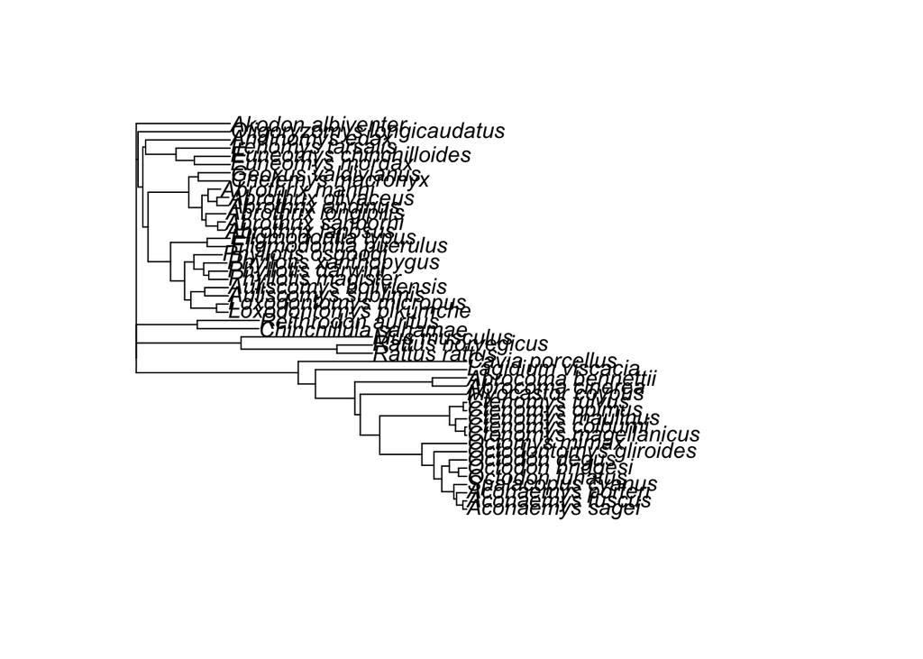

```r
phy<- read.nexus("tree/output.nex")
consensus<-consensus.edges(phy, consensus.tree=consensus(phy,p=0.5))  #ape for majority rule consensus
plot(consensus)
```

```r
cc<- read.csv("ClosenessCentralityHanta.csv", header=T, row.names = 1)
row.names(cc)<- sub(" ", "_", row.names(cc))
```

Fit the model and plot the curve

```r
tre<- consensus
cc<-cc[order(match(row.names(cc),tre$tip.label)),]
set.seed(123456)

class(tre)
```

```
## [1] "phylo"
```

```r
summary(tre)
```

```
##
## Phylogenetic tree: tre
##
##   Number of tips: 48
##   Number of nodes: 46
##   Branch lengths:
##     mean: 6.125721
##     variance: 55.60643
##     distribution summary:
##      Min.   1st Qu.    Median   3rd Qu.      Max.
##  0.000000  1.586229  2.868166  7.292117 34.591102
##   No root edge.
##   First ten tip labels: Cavia_porcellus
##                         Octodontomys_gliroides
##                         Octodon_degus
##                         Octodon_lunatus
##                         Octodon_bridgesi
##                         Spalacopus_cyanus
##                         Aconaemys_porteri
##                         Aconaemys_sagei
##                         Aconaemys_fuscus
##                         Octomys_mimax
##   First ten node labels: 1
##                          1
##                          1
##                          1
##                          1
##                          1
##                          1
##                          1
##                          1
##                          1
```

```r
fit = phyloglm(X ~ closnesscentrality, tre, data=cc, boot=100)
summary(fit)
```

```
##
## Call:
## phyloglm(formula = X ~ closnesscentrality, data = cc, phy = tre,
##     boot = 100)
##        AIC     logLik Pen.logLik
##     23.295     -8.648     -9.666
##
## Method: logistic_MPLE
## Mean tip height: 40.36665
## Parameter estimate(s):
## alpha: 0.0004625733
##       bootstrap mean: 0.002489067 (on log scale, then back transformed)
##       so possible upward bias.
##       bootstrap 95% CI: (0.0004543538,0.9567479)
##
## Coefficients:
##                    Estimate   StdErr  z.value lowerbootCI upperbootCI  p.value
## (Intercept)         -6.2937   2.3342  -2.6962    -13.8907     -3.4264 0.007013
## closnesscentrality   9.9426   3.1622   3.1442      5.9304     22.6024 0.001666
##
## (Intercept)        **
## closnesscentrality **
## ---
## Signif. codes:  0 '***' 0.001 '**' 0.01 '*' 0.05 '.' 0.1 ' ' 1
##
## Note: Wald-type p-values for coefficients, conditional on alpha=0.0004625733
##       Parametric bootstrap results based on 100 fitted replicates
```

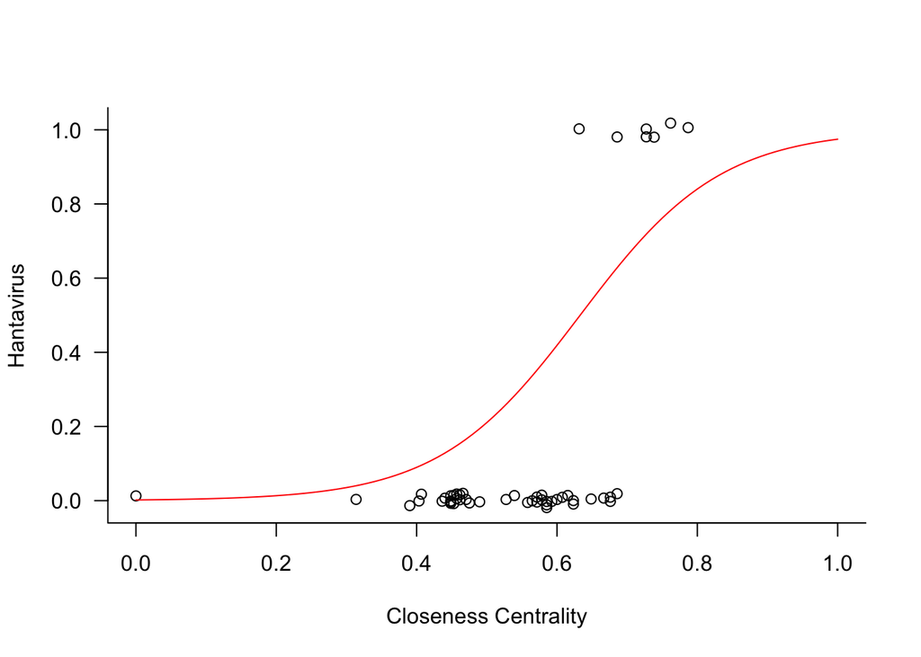

```r
par(las=1,bty="l") ## cosmetic
plot(cc$closnesscentrality,jitter(cc$X,factor=0,amount=0.02),
     xlab="Closeness Centrality",ylab="Hantavirus",xlim=c(0,1))
cf <- coef(fit)
x=cc$closnesscentrality
curve(plogis(cf[1]+cf[2]*x),col="red",add=TRUE)
```